# **Regression Project: Boston House Price Prediction**

Welcome to the project on regression. We will use the **Boston house price dataset** for this project.

## **Objective**

The problem at hand is to **predict the housing prices of a town or a suburb based on the features of the locality provided to us**. In the process, we need to **identify the most important features affecting the price of the house**. We need to employ techniques of data preprocessing and build a linear regression model that predicts the prices for the unseen data.

## **Dataset**

Each record in the database describes a house in Boston suburb or town. The data was drawn from the Boston Standard Metropolitan Statistical Area (SMSA) in 1970. Detailed attribute information can be found below:

Attribute Information:

- **CRIM:** Per capita crime rate by town
- **ZN:** Proportion of residential land zoned for lots over 25,000 sq.ft.
- **INDUS:** Proportion of non-retail business acres per town
- **CHAS:** Charles River dummy variable (= 1 if tract bounds river; 0 otherwise)
- **NOX:** Nitric Oxide concentration (parts per 10 million)
- **RM:** The average number of rooms per dwelling
- **AGE:** Proportion of owner-occupied units built before 1940
- **DIS:** Weighted distances to five Boston employment centers
- **RAD:** Index of accessibility to radial highways
- **TAX:** Full-value property-tax rate per 10,000 dollars
- **PTRATIO:** Pupil-teacher ratio by town
- **LSTAT:** % lower status of the population
- **MEDV:** Median value of owner-occupied homes in 1000 dollars

## **Importing the necessary libraries**

```python
import numpy as np

import pandas as pd

import matplotlib.pyplot as plt

import seaborn as sns

from statsmodels.formula.api import ols

import statsmodels.api as sm

from statsmodels.stats.outliers_influence import variance_inflation_factor

from sklearn.metrics import r2_score, mean_absolute_percentage_error, mean_absolute_error, mean_squared_error

from sklearn.model_selection import train_test_split

from statsmodels.stats.diagnostic import het_white

from statsmodels.compat import lzip

import statsmodels.stats.api as sms

import pylab

import scipy.stats as stats

from sklearn.model_selection import KFold

import sklearn

import warnings
warnings.filterwarnings("ignore")
```

```python
from google.colab import drive
drive.mount('/content/drive')
```

### Loading the dataset

```python
data = pd.read_csv('/content/drive/MyDrive/MIT course/Elective Project/Boston.csv')
```

## Data Overview

- Observations
- Sanity checks

```python
data.head()
```

|  | CRIM | ZN | INDUS | CHAS | NOX | RM | AGE | DIS | RAD | TAX | PTRATIO | LSTAT | MEDV |
| --- | --- | --- | --- | --- | --- | --- | --- | --- | --- | --- | --- | --- | --- |
| 0 | 0.00632 | 18.0 | 2.31 | 0 | 0.538 | 6.575 | 65.2 | 4.0900 | 1 | 296 | 15.3 | 4.98 | 24.0 |
| 1 | 0.02731 | 0.0 | 7.07 | 0 | 0.469 | 6.421 | 78.9 | 4.9671 | 2 | 242 | 17.8 | 9.14 | 21.6 |
| 2 | 0.02729 | 0.0 | 7.07 | 0 | 0.469 | 7.185 | 61.1 | 4.9671 | 2 | 242 | 17.8 | 4.03 | 34.7 |
| 3 | 0.03237 | 0.0 | 2.18 | 0 | 0.458 | 6.998 | 45.8 | 6.0622 | 3 | 222 | 18.7 | 2.94 | 33.4 |
| 4 | 0.06905 | 0.0 | 2.18 | 0 | 0.458 | 7.147 | 54.2 | 6.0622 | 3 | 222 | 18.7 | 5.33 | 36.2 |

```python
# Check data dimensions
data.shape
```

```
(506, 13)
```

```python
data.info()
```

```
<class 'pandas.core.frame.DataFrame'>
RangeIndex: 506 entries, 0 to 505
Data columns (total 13 columns):
 #   Column   Non-Null Count  Dtype
---  ------   --------------  -----
 0   CRIM     506 non-null    float64
 1   ZN       506 non-null    float64
 2   INDUS    506 non-null    float64
 3   CHAS     506 non-null    int64
 4   NOX      506 non-null    float64
 5   RM       506 non-null    float64
 6   AGE      506 non-null    float64
 7   DIS      506 non-null    float64
 8   RAD      506 non-null    int64
 9   TAX      506 non-null    int64
 10  PTRATIO  506 non-null    float64
 11  LSTAT    506 non-null    float64
 12  MEDV     506 non-null    float64
dtypes: float64(10), int64(3)
memory usage: 51.5 KB
```

```python
# Checking for duplicate values in the data
data.duplicated().sum()
```

```
0
```

```python
# Checking the descriptive statistics of the columns
data.describe().T
```

|  | count | mean | std | min | 25% | 50% | 75% | max |
| --- | --- | --- | --- | --- | --- | --- | --- | --- |
| CRIM | 506.0 | 3.613524 | 8.601545 | 0.00632 | 0.082045 | 0.25651 | 3.677083 | 88.9762 |
| ZN | 506.0 | 11.363636 | 23.322453 | 0.00000 | 0.000000 | 0.00000 | 12.500000 | 100.0000 |
| INDUS | 506.0 | 11.136779 | 6.860353 | 0.46000 | 5.190000 | 9.69000 | 18.100000 | 27.7400 |
| CHAS | 506.0 | 0.069170 | 0.253994 | 0.00000 | 0.000000 | 0.00000 | 0.000000 | 1.0000 |
| NOX | 506.0 | 0.554695 | 0.115878 | 0.38500 | 0.449000 | 0.53800 | 0.624000 | 0.8710 |
| RM | 506.0 | 6.284634 | 0.702617 | 3.56100 | 5.885500 | 6.20850 | 6.623500 | 8.7800 |
| AGE | 506.0 | 68.574901 | 28.148861 | 2.90000 | 45.025000 | 77.50000 | 94.075000 | 100.0000 |
| DIS | 506.0 | 3.795043 | 2.105710 | 1.12960 | 2.100175 | 3.20745 | 5.188425 | 12.1265 |
| RAD | 506.0 | 9.549407 | 8.707259 | 1.00000 | 4.000000 | 5.00000 | 24.000000 | 24.0000 |
| TAX | 506.0 | 408.237154 | 168.537116 | 187.00000 | 279.000000 | 330.00000 | 666.000000 | 711.0000 |
| PTRATIO | 506.0 | 18.455534 | 2.164946 | 12.60000 | 17.400000 | 19.05000 | 20.200000 | 22.0000 |
| LSTAT | 506.0 | 12.653063 | 7.141062 | 1.73000 | 6.950000 | 11.36000 | 16.955000 | 37.9700 |
| MEDV | 506.0 | 22.532806 | 9.197104 | 5.00000 | 17.025000 | 21.20000 | 25.000000 | 50.0000 |

**Observations:**

- There are no Null values within the data.
- All the variables are numeric.
- The dependent variable in this scenario is MEDV
- There are outliers in certain variables like in ZN.

## Exploratory Data Analysis (EDA)

```python
# Function to plot a boxplot and a histogram along the same scale
def plot_box_hist(data, feature):
    """
    Plots a boxplot and a histogram of the given feature along the same scale.

    Parameters:
    data (DataFrame): The dataset containing the features.
    feature (str): The name of the feature to plot.
    """
    fig, axes = plt.subplots(nrows=1, ncols=2, figsize=(12, 6))

    # Boxplot
    sns.boxplot(data=data, x=feature, ax=axes[0])
    axes[0].set_title(f'Boxplot of {feature}')


    # Histogram
    sns.histplot(data=data, x=feature, kde=True, ax=axes[1])
    axes[1].set_title(f'Histogram of {feature}')

    # Set the same x-axis limits for both plots
    xmin = min(data[feature])
    xmax = max(data[feature])
    axes[0].set_xlim([xmin, xmax])
    axes[1].set_xlim([xmin, xmax])

    plt.tight_layout()
    plt.show()
```

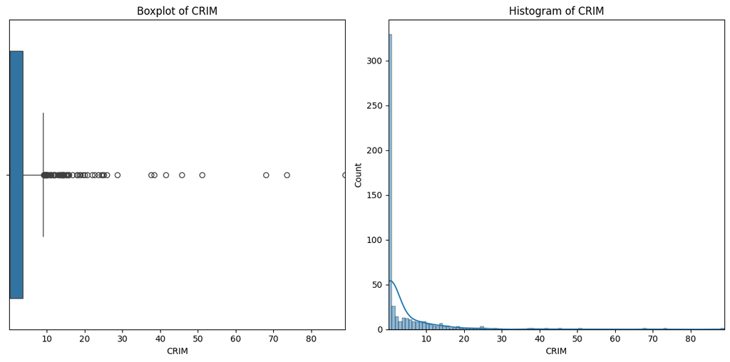

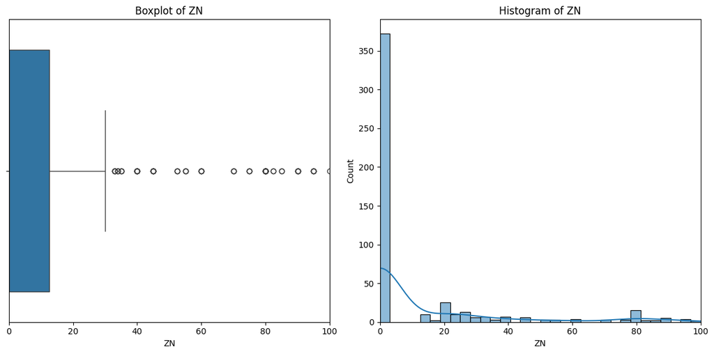

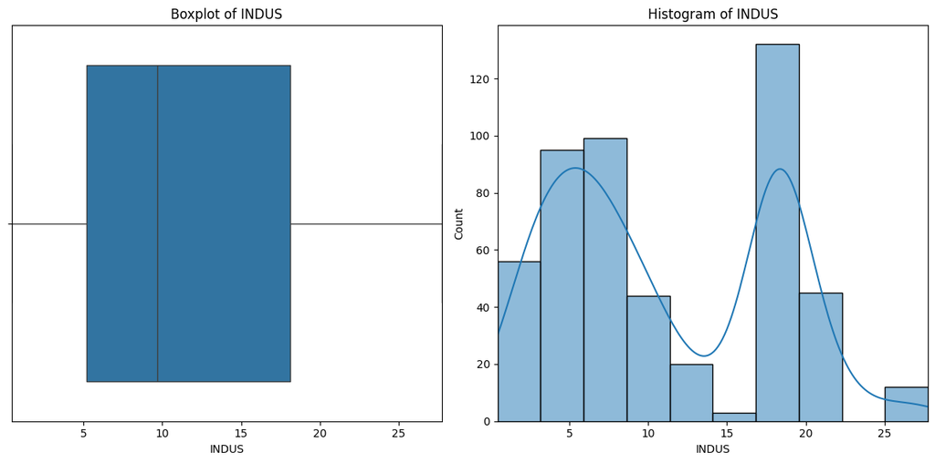

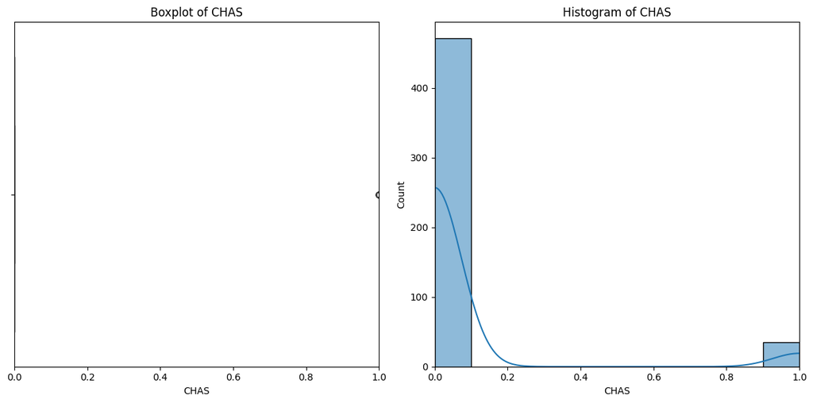

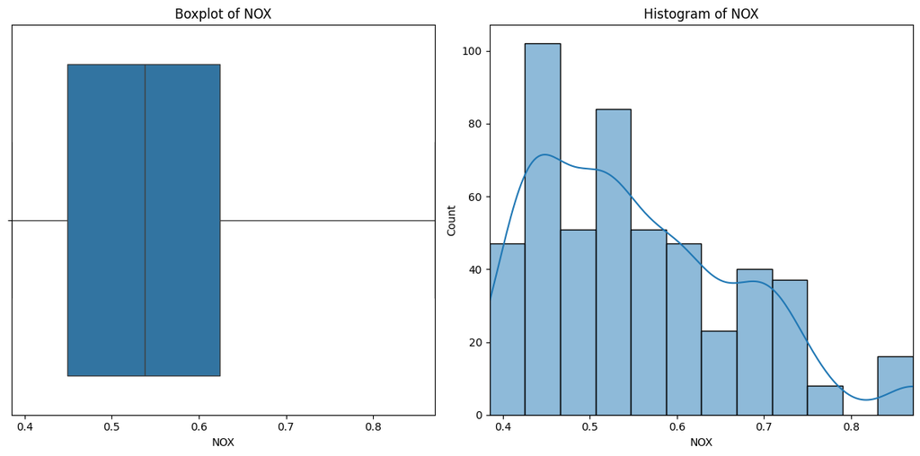

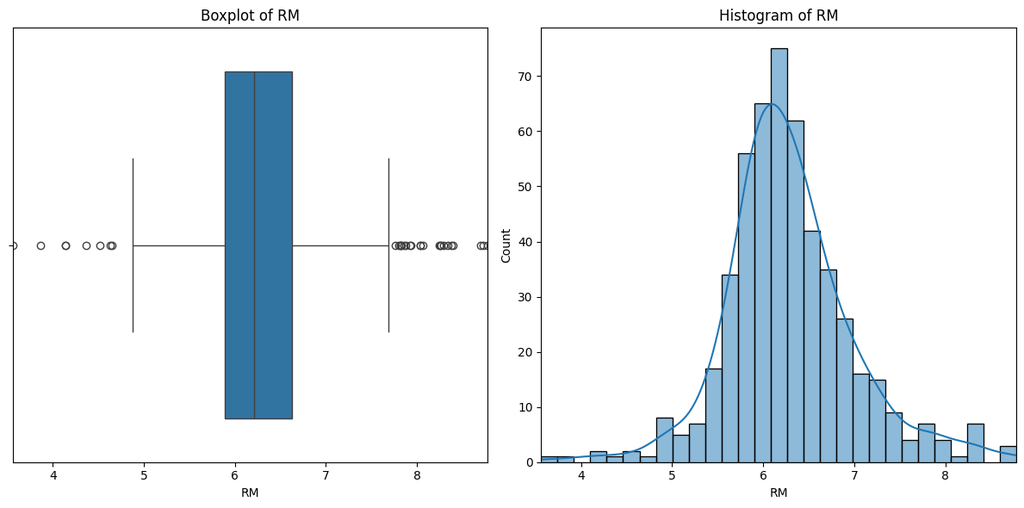

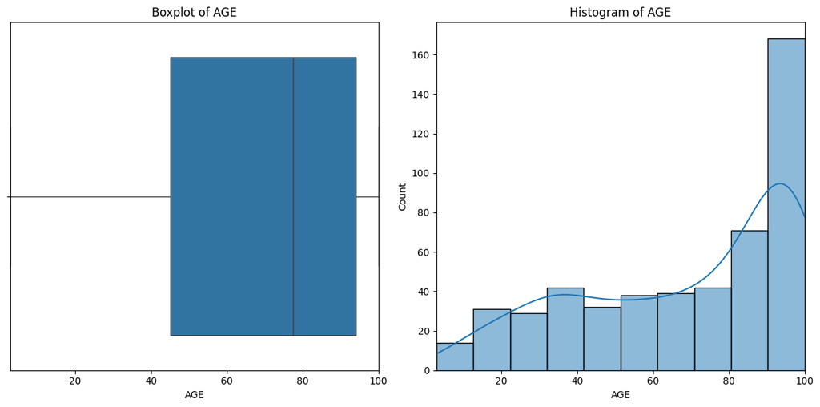

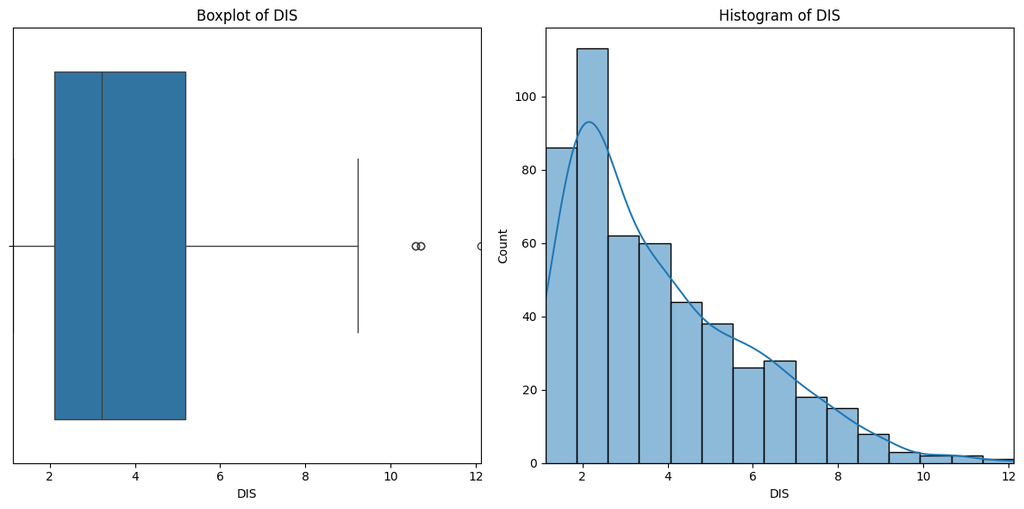

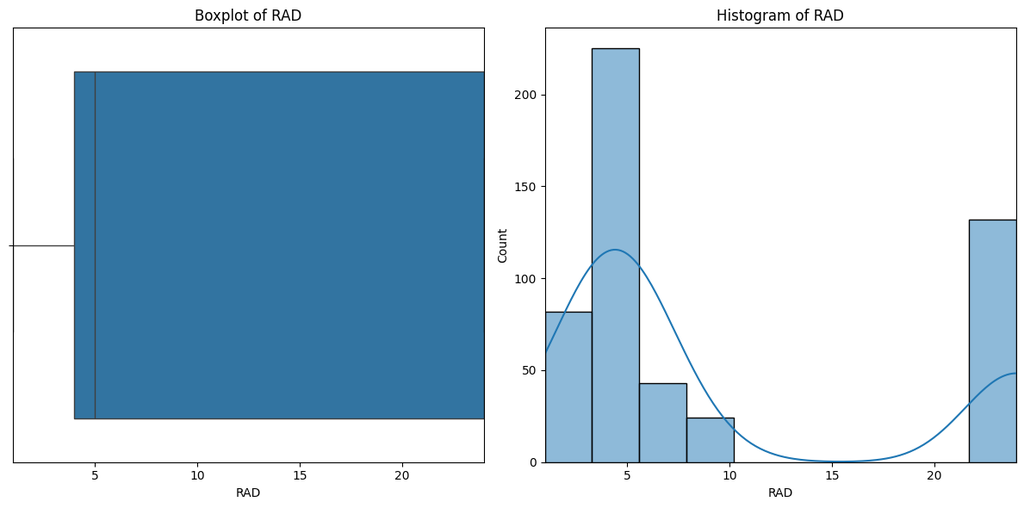

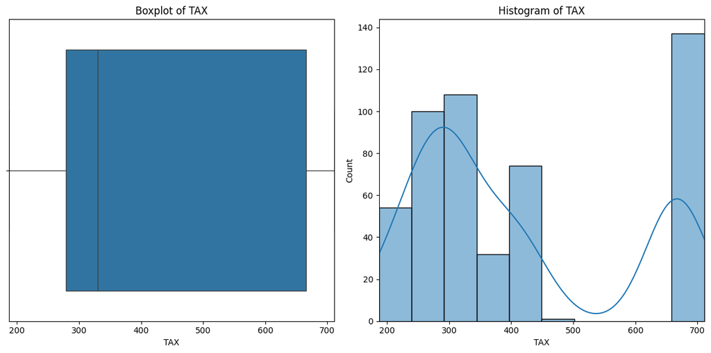

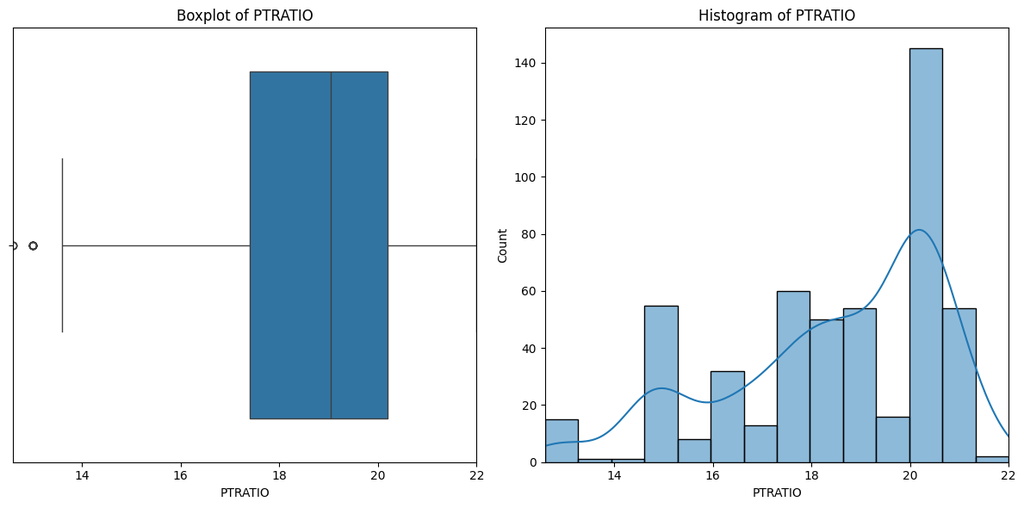

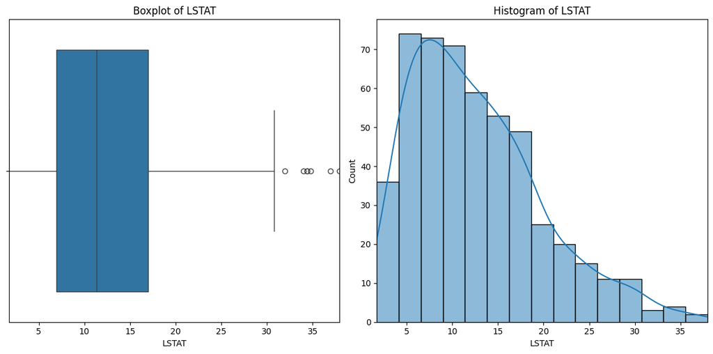

[1 more figures not shown]

```python
# Plot all the distributions of the variables
for feature in data.columns:
  plot_box_hist(data, feature)
```

**Observations:**

- Almost all the variables don't have a normal distribution, they are also very skewed.
- In the case of the variable CHAS, there is no distribution since it is binary, however, most houses are not close to the Charles River.
- TAX distribution has a distinct drop after 500 and then another spike at 700. Perhaps this is due to a correlation with another variable. Something similar happens with the variable RAD.
- The dependent variable, MEDV, is slightly skewed to the right, so computing a log transform might be useful to achieve normality.

**Bivariate analysis**

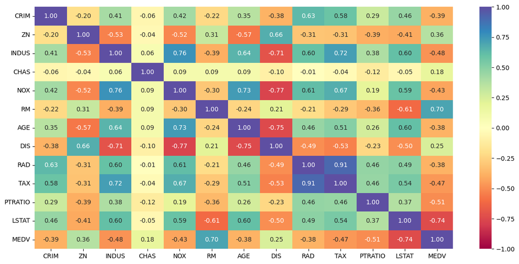

```python
# Finding the correlation between various columns of the dataset
plt.figure(figsize = (15,7))
sns.heatmap(data.corr(), annot = True, vmin = -1, vmax = 1, fmt = ".2f", cmap = "Spectral")
```

**Observations**:

- There is significant correlation between some variables:
- TAX and INDUS of 0.72
- NOX and INDUS of 0.76
- DIS and INDUS of -0.71
- AGE and NOX of 0.73
- DIS and NOX of -0.77
- MEDV and RM of 0.7
- DIS and AGE of -0.75
- TAX and RAD of 0.91
- LSTAT and MEDV of -0.74
- The dependent variable only has a correlation of more than |0.7| with two variables, RM and LSTAT

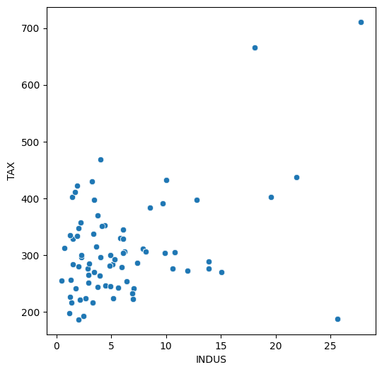

```python
# Scatterplot for INDUS and TAX
plt.figure(figsize = (6, 6))
sns.scatterplot(x = 'INDUS', y = 'TAX', data = data)
plt.show()
```

**Observations:**

- As INDUS increases, TAX increases, this can be due that there is also correlation between these two variables and NOX, which is the Nitric Oxide concentration, so it makes sense that when the non-retail businesses increase, contamination increases and so does taxes.

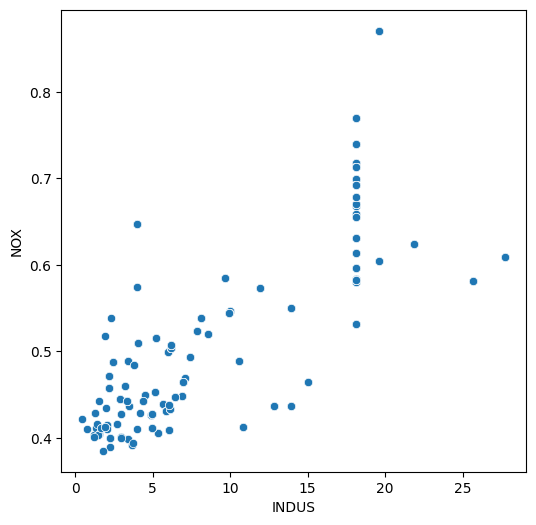

```python
# Scatterplot for INDUS and NOX
plt.figure(figsize = (6, 6))
sns.scatterplot(x = 'INDUS', y = 'NOX', data = data)
plt.show()
```

**Observations:**

- As industrial activities increase, the amount of air pollution due to Nitric Oxide increases

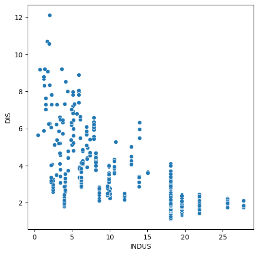

```python
# Scatterplot for DIS and INDUS
plt.figure(figsize = (6, 6))
sns.scatterplot(x = 'INDUS', y = 'DIS', data = data)
plt.show()
```

**Observations:**

- When the proportion of non-retail businesses increase, the distance between employment centers and towns decrease

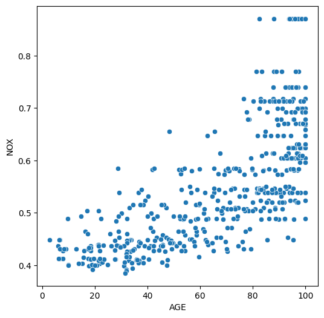

```python
# Scatterplot for AGE and NOX
plt.figure(figsize = (6, 6))
sns.scatterplot(x = 'AGE', y = 'NOX', data = data)
plt.show()
```

**Observations:**

- As age increases, Nitric Oxide increases, this makes little sense by its own, however, these two variables have significant correlation with DIS, so this would explain it. Older buildings are closer to industrial sites, so, the NOX variable is higher.

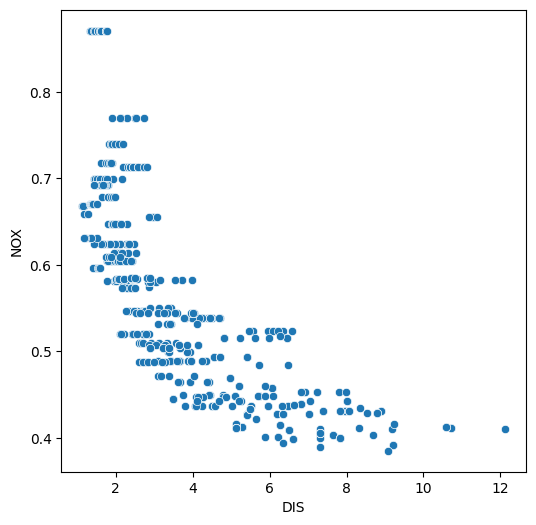

```python
# Scatterplot for DIS and NOX
plt.figure(figsize = (6, 6))
sns.scatterplot(x = 'DIS', y = 'NOX', data = data)
plt.show()
```

**Observations:**

- The lower the distance between a town and industrial sites, the higher the air pollution.

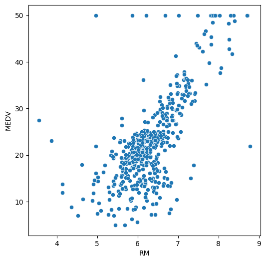

```python
# Scatterplot for MEDV and RM
plt.figure(figsize = (6, 6))
sns.scatterplot(x = 'RM', y = 'MEDV', data = data)
plt.show()
```

**Observations:**

- This positive correlation makes sense, the more rooms per dwelling, the higher the price.

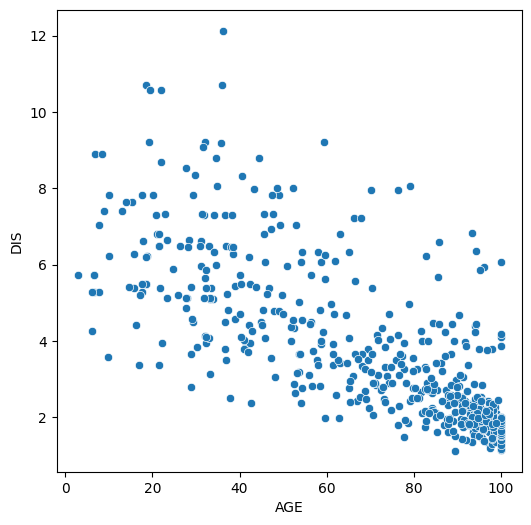

```python
# Scatterplot for DIS and AGE
plt.figure(figsize = (6, 6))
sns.scatterplot(x = 'AGE', y = 'DIS', data = data)
plt.show()
```

**Observations:**

- Towns with older buildings are closer to employment centers.

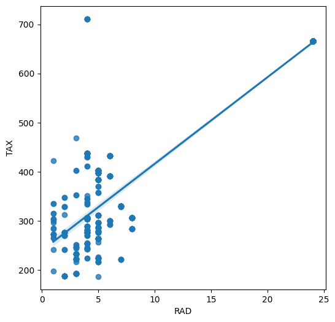

```python
# Scatterplot for TAX and RAD
plt.figure(figsize = (6, 6))
sns.regplot(x = 'RAD', y = 'TAX', data = data)
plt.show()
```

**Observations:**

- This plot does not follow any trend, perhaps the correlation is due to the outliers

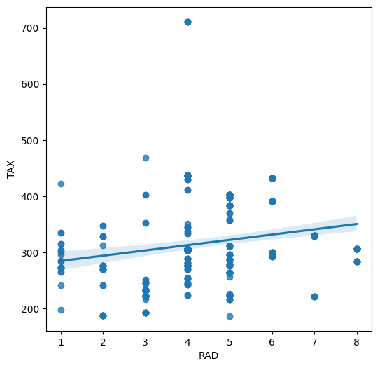

```python
test_df = data[data['RAD'] < 10]
plt.figure(figsize = (6, 6))
sns.regplot(x = 'RAD', y = 'TAX', data = test_df)
plt.show()
```

```python
test_df.corr()
```

|  | CRIM | ZN | INDUS | CHAS | NOX | RM | AGE | DIS | RAD | TAX | PTRATIO | LSTAT | MEDV |
| --- | --- | --- | --- | --- | --- | --- | --- | --- | --- | --- | --- | --- | --- |
| CRIM | 1.000000 | -0.288726 | 0.500636 | 0.135539 | 0.746568 | -0.212319 | 0.468386 | -0.446093 | 0.145992 | 0.295886 | -0.237853 | 0.384030 | -0.171697 |
| ZN | -0.288726 | 1.000000 | -0.470373 | -0.057796 | -0.475555 | 0.313877 | -0.531523 | 0.635556 | -0.168458 | -0.128271 | -0.300973 | -0.393447 | 0.326101 |
| INDUS | 0.500636 | -0.470373 | 1.000000 | 0.107334 | 0.666886 | -0.391950 | 0.542954 | -0.602261 | -0.004461 | 0.518329 | 0.134352 | 0.534288 | -0.389719 |
| CHAS | 0.135539 | -0.057796 | 0.107334 | 1.000000 | 0.121360 | 0.047722 | 0.122706 | -0.136626 | 0.087884 | -0.047599 | -0.145399 | 0.053330 | 0.095457 |
| NOX | 0.746568 | -0.475555 | 0.666886 | 0.121360 | 1.000000 | -0.274146 | 0.671789 | -0.716061 | 0.125672 | 0.380057 | -0.152672 | 0.498434 | -0.263013 |
| RM | -0.212319 | 0.313877 | -0.391950 | 0.047722 | -0.274146 | 1.000000 | -0.178846 | 0.106284 | 0.070815 | -0.262646 | -0.344239 | -0.685705 | 0.890823 |
| AGE | 0.468386 | -0.531523 | 0.542954 | 0.122706 | 0.671789 | -0.178846 | 1.000000 | -0.678700 | 0.096003 | 0.274303 | 0.061438 | 0.549854 | -0.268203 |
| DIS | -0.446093 | 0.635556 | -0.602261 | -0.136626 | -0.716061 | 0.106284 | -0.678700 | 1.000000 | -0.081962 | -0.249518 | 0.002858 | -0.364162 | 0.071600 |
| RAD | 0.145992 | -0.168458 | -0.004461 | 0.087884 | 0.125672 | 0.070815 | 0.096003 | -0.081962 | 1.000000 | 0.188256 | -0.057767 | -0.001163 | 0.074820 |
| TAX | 0.295886 | -0.128271 | 0.518329 | -0.047599 | 0.380057 | -0.262646 | 0.274303 | -0.249518 | 0.188256 | 1.000000 | 0.068625 | 0.314399 | -0.330454 |
| PTRATIO | -0.237853 | -0.300973 | 0.134352 | -0.145399 | -0.152672 | -0.344239 | 0.061438 | 0.002858 | -0.057767 | 0.068625 | 1.000000 | 0.217655 | -0.460227 |
| LSTAT | 0.384030 | -0.393447 | 0.534288 | 0.053330 | 0.498434 | -0.685705 | 0.549854 | -0.364162 | -0.001163 | 0.314399 | 0.217655 | 1.000000 | -0.672585 |
| MEDV | -0.171697 | 0.326101 | -0.389719 | 0.095457 | -0.263013 | 0.890823 | -0.268203 | 0.071600 | 0.074820 | -0.330454 | -0.460227 | -0.672585 | 1.000000 |

**Observations:**

- If outliers are taken out, the correlation between these two variables is of ~0.19, so it is not of significance.

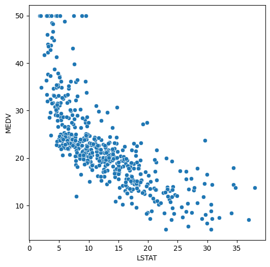

```python
# Scatterplot for LSTAT and MEDV
plt.figure(figsize = (6, 6))
sns.scatterplot(x = 'LSTAT', y = 'MEDV', data = data)
plt.show()
```

**Observations:**

- As the amount of people with low socioeconomic status increases, house prices drop. This makes sense since most people would not be able to afford housing if princes were higher.

## Data Preprocessing

```python
# Apply log transformation to the dependent variable
data['MEDV'] = np.log(data['MEDV'])
```

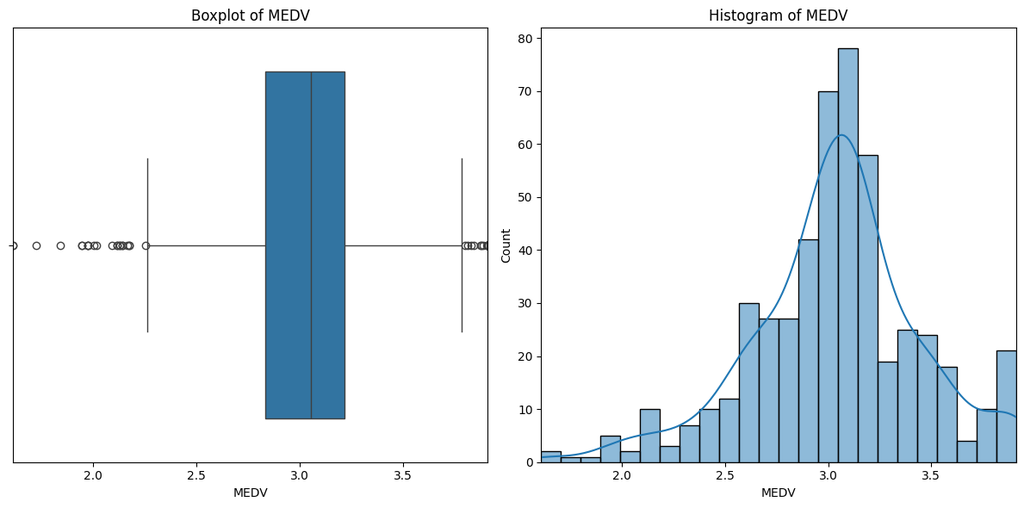

```python
plot_box_hist(data, 'MEDV')
```

**Observation:**

- With the log transformation, the dependent variable seems a little more normally distributed and less skewed.
- There are no null values to be treated.
- The outliers don't need to be treated since they are proper values.

## Model Building - Linear Regression

```python
# Take dependent and independent variables
y = data['MEDV']
x = data.drop(columns = 'MEDV')

# Add constant
x = sm.add_constant(x)
```

```python
# Split the data 15% for testing, 85% for training

x_train, x_test, y_train, y_test = train_test_split(x, y, test_size = 0.15, random_state = 1)
```

```python
# Check for multicollinearity

# Function to check VIF
def checking_vif(train):
    vif = pd.DataFrame()
    vif["feature"] = train.columns

    # Calculating VIF for each feature
    vif["VIF"] = [
        variance_inflation_factor(train.values, i) for i in range(len(train.columns))
    ]
    return vif

print(checking_vif(x_train))
```

```
    feature         VIF
0     const  535.200091
1      CRIM    1.739110
2        ZN    2.504154
3     INDUS    3.901991
4      CHAS    1.069708
5       NOX    4.378652
6        RM    1.927099
7       AGE    3.256620
8       DIS    4.152061
9       RAD    7.639489
10      TAX    9.318876
11  PTRATIO    1.816933
12    LSTAT    2.980971
```

```python
# Remove TAX since it has the highest collinearity
x_train.drop(columns = 'TAX', inplace = True)
x_test.drop(columns = 'TAX', inplace = True)
```

```python
x_train.head()
```

|  | const | CRIM | ZN | INDUS | CHAS | NOX | RM | AGE | DIS | RAD | PTRATIO | LSTAT |
| --- | --- | --- | --- | --- | --- | --- | --- | --- | --- | --- | --- | --- |
| 370 | 1.0 | 6.53876 | 0.0 | 18.10 | 1 | 0.631 | 7.016 | 97.5 | 1.2024 | 24 | 20.2 | 2.96 |
| 285 | 1.0 | 0.01096 | 55.0 | 2.25 | 0 | 0.389 | 6.453 | 31.9 | 7.3073 | 1 | 15.3 | 8.23 |
| 159 | 1.0 | 1.42502 | 0.0 | 19.58 | 0 | 0.871 | 6.510 | 100.0 | 1.7659 | 5 | 14.7 | 7.39 |
| 291 | 1.0 | 0.07886 | 80.0 | 4.95 | 0 | 0.411 | 7.148 | 27.7 | 5.1167 | 4 | 19.2 | 3.56 |
| 128 | 1.0 | 0.32543 | 0.0 | 21.89 | 0 | 0.624 | 6.431 | 98.8 | 1.8125 | 4 | 21.2 | 15.39 |

```python
print(checking_vif(x_train))
```

```
    feature         VIF
0     const  529.939355
1      CRIM    1.738776
2        ZN    2.338177
3     INDUS    3.175019
4      CHAS    1.052718
5       NOX    4.352911
6        RM    1.918919
7       AGE    3.250590
8       DIS    4.150677
9       RAD    2.702143
10  PTRATIO    1.799632
11    LSTAT    2.978939
```

Now all of the variables have a VIF of less than 5. There is no longer multicollinearity between variables.

```python
# Model Performance on test and train data
def model_performance(olsmodel, x_train, x_test):

    # In-sample Prediction
    y_pred_train = olsmodel.predict(x_train)
    y_observed_train = y_train

    # Prediction on test data
    y_pred_test = olsmodel.predict(x_test)
    y_observed_test = y_test

    print(
        pd.DataFrame(
            {
                "Data": ["Train", "Test"],
                "RMSE": [
                    np.sqrt(mean_squared_error(y_observed_train, y_pred_train)),
                    np.sqrt(mean_squared_error(y_observed_test,y_pred_test)),
                ],
                "MAE": [
                    mean_absolute_error(y_observed_train, y_pred_train),
                    mean_absolute_error(y_observed_test,y_pred_test),
                ],
                "MAPE": [
                    mean_absolute_percentage_error(y_observed_train, y_pred_train),
                    mean_absolute_percentage_error(y_observed_test,y_pred_test),
                ],

                'r2': [
                    r2_score(y_observed_train, y_pred_train),
                    r2_score(y_observed_test,y_pred_test),
                ],
            }
        )
    )
```

```python
# Create model
model_1 = sm.OLS(y_train, x_train).fit()

# Check model summary
model_1.summary()
```

OLS Regression Results

| Dep. Variable: | MEDV | R-squared: | 0.780 |
| --- | --- | --- | --- |
| Model: | OLS | Adj. R-squared: | 0.774 |
| Method: | Least Squares | F-statistic: | 134.4 |
| Date: | Mon, 27 May 2024 | Prob (F-statistic): | 1.04e-129 |
| Time: | 20:16:10 | Log-Likelihood: | 103.59 |
| No. Observations: | 430 | AIC: | -183.2 |
| Df Residuals: | 418 | BIC: | -134.4 |
| Df Model: | 11 |  |  |
| Covariance Type: | nonrobust |  |  |

|  | coef | std err | t | P>\|t\| | [0.025 | 0.975] |
| --- | --- | --- | --- | --- | --- | --- |
| const | 4.2916 | 0.214 | 20.043 | 0.000 | 3.871 | 4.712 |
| CRIM | -0.0110 | 0.001 | -8.144 | 0.000 | -0.014 | -0.008 |
| ZN | 0.0010 | 0.001 | 1.581 | 0.115 | -0.000 | 0.002 |
| INDUS | -0.0024 | 0.002 | -0.988 | 0.324 | -0.007 | 0.002 |
| CHAS | 0.1210 | 0.036 | 3.374 | 0.001 | 0.050 | 0.191 |
| NOX | -0.9178 | 0.166 | -5.524 | 0.000 | -1.244 | -0.591 |
| RM | 0.0814 | 0.019 | 4.365 | 0.000 | 0.045 | 0.118 |
| AGE | 0.0005 | 0.001 | 0.881 | 0.379 | -0.001 | 0.002 |
| DIS | -0.0502 | 0.009 | -5.617 | 0.000 | -0.068 | -0.033 |
| RAD | 0.0052 | 0.002 | 2.936 | 0.004 | 0.002 | 0.009 |
| PTRATIO | -0.0392 | 0.006 | -6.876 | 0.000 | -0.050 | -0.028 |
| LSTAT | -0.0300 | 0.002 | -13.317 | 0.000 | -0.034 | -0.026 |

| Omnibus: | 39.523 | Durbin-Watson: | 1.976 |
| --- | --- | --- | --- |
| Prob(Omnibus): | 0.000 | Jarque-Bera (JB): | 130.953 |
| Skew: | 0.349 | Prob(JB): | 3.66e-29 |
| Kurtosis: | 5.612 | Cond. No. | 2.06e+03 |

Notes:  
[1] Standard Errors assume that the covariance matrix of the errors is correctly specified.  
[2] The condition number is large, 2.06e+03. This might indicate that there are  
strong multicollinearity or other numerical problems.

## Model Performance Check

```python
# Evaluate model's performance
model_performance(model_1, x_train, x_test)
```

```
    Data      RMSE       MAE      MAPE        r2
0  Train  0.190167  0.137504  0.047765  0.779549
1   Test  0.212692  0.161786  0.057654  0.750711
```

The metrics differ between testing and training data, there may be slight overfitting happening. Changing the ratio of training/testing data might be helpful.

```python
# Split the data with a new ratio
x_train, x_test, y_train, y_test = train_test_split(x, y, test_size = 0.35, random_state = 1)

# Drop TAX column, as it has a high VIF value
x_train.drop(columns = 'TAX', inplace = True)
x_test.drop(columns = 'TAX', inplace = True)

# Check that all VIF values are < 5
print(checking_vif(x_train))
```

```
    feature         VIF
0     const  571.184053
1      CRIM    1.895501
2        ZN    2.522618
3     INDUS    3.187149
4      CHAS    1.046378
5       NOX    4.255035
6        RM    2.045091
7       AGE    3.181671
8       DIS    4.333145
9       RAD    2.906020
10  PTRATIO    1.978790
11    LSTAT    3.080552
```

```python
# Create model 2
model_2 = sm.OLS(y_train, x_train).fit()

# Check summary
model_2.summary()
```

OLS Regression Results

| Dep. Variable: | MEDV | R-squared: | 0.772 |
| --- | --- | --- | --- |
| Model: | OLS | Adj. R-squared: | 0.764 |
| Method: | Least Squares | F-statistic: | 97.04 |
| Date: | Mon, 27 May 2024 | Prob (F-statistic): | 2.42e-94 |
| Time: | 20:16:10 | Log-Likelihood: | 66.666 |
| No. Observations: | 328 | AIC: | -109.3 |
| Df Residuals: | 316 | BIC: | -63.82 |
| Df Model: | 11 |  |  |
| Covariance Type: | nonrobust |  |  |

|  | coef | std err | t | P>\|t\| | [0.025 | 0.975] |
| --- | --- | --- | --- | --- | --- | --- |
| const | 4.4664 | 0.265 | 16.824 | 0.000 | 3.944 | 4.989 |
| CRIM | -0.0129 | 0.002 | -7.331 | 0.000 | -0.016 | -0.009 |
| ZN | 0.0010 | 0.001 | 1.340 | 0.181 | -0.000 | 0.003 |
| INDUS | -7.105e-05 | 0.003 | -0.025 | 0.980 | -0.006 | 0.006 |
| CHAS | 0.1337 | 0.041 | 3.235 | 0.001 | 0.052 | 0.215 |
| NOX | -1.0378 | 0.193 | -5.363 | 0.000 | -1.418 | -0.657 |
| RM | 0.0711 | 0.024 | 3.025 | 0.003 | 0.025 | 0.117 |
| AGE | 0.0004 | 0.001 | 0.597 | 0.551 | -0.001 | 0.002 |
| DIS | -0.0479 | 0.011 | -4.418 | 0.000 | -0.069 | -0.027 |
| RAD | 0.0074 | 0.002 | 3.408 | 0.001 | 0.003 | 0.012 |
| PTRATIO | -0.0446 | 0.007 | -6.215 | 0.000 | -0.059 | -0.031 |
| LSTAT | -0.0289 | 0.003 | -10.934 | 0.000 | -0.034 | -0.024 |

| Omnibus: | 31.315 | Durbin-Watson: | 1.867 |
| --- | --- | --- | --- |
| Prob(Omnibus): | 0.000 | Jarque-Bera (JB): | 91.283 |
| Skew: | 0.388 | Prob(JB): | 1.51e-20 |
| Kurtosis: | 5.465 | Cond. No. | 2.14e+03 |

Notes:  
[1] Standard Errors assume that the covariance matrix of the errors is correctly specified.  
[2] The condition number is large, 2.14e+03. This might indicate that there are  
strong multicollinearity or other numerical problems.

```python
# Check model's performance
model_performance(model_2, x_train, x_test)
```

```
    Data      RMSE       MAE      MAPE        r2
0  Train  0.197466  0.143189  0.050054  0.771587
1   Test  0.191158  0.143477  0.049691  0.769924
```

Model performance may be improved by removing unnecesary variables (p-value > 0.05)

```python
# Remove unnecesary variables on both training and testing sets
x_train_2 = x_train.drop(columns = ['INDUS', 'ZN', 'AGE'])
x_test_2 = x_test.drop(columns = ['INDUS', 'ZN', 'AGE'])

# Check VIF values
print(checking_vif(x_train_2))
```

```
   feature         VIF
0    const  564.784511
1     CRIM    1.862987
2     CHAS    1.044680
3      NOX    3.465392
4       RM    1.884616
5      DIS    2.575430
6      RAD    2.802494
7  PTRATIO    1.636511
8    LSTAT    2.603805
```

```python
# Build model 3
model_3 = sm.OLS(y_train, x_train_2).fit()

# Check model summary
model_3.summary()
```

OLS Regression Results

| Dep. Variable: | MEDV | R-squared: | 0.770 |
| --- | --- | --- | --- |
| Model: | OLS | Adj. R-squared: | 0.764 |
| Method: | Least Squares | F-statistic: | 133.6 |
| Date: | Mon, 27 May 2024 | Prob (F-statistic): | 4.58e-97 |
| Time: | 20:16:11 | Log-Likelihood: | 65.633 |
| No. Observations: | 328 | AIC: | -113.3 |
| Df Residuals: | 319 | BIC: | -79.13 |
| Df Model: | 8 |  |  |
| Covariance Type: | nonrobust |  |  |

|  | coef | std err | t | P>\|t\| | [0.025 | 0.975] |
| --- | --- | --- | --- | --- | --- | --- |
| const | 4.4696 | 0.264 | 16.957 | 0.000 | 3.951 | 4.988 |
| CRIM | -0.0126 | 0.002 | -7.243 | 0.000 | -0.016 | -0.009 |
| CHAS | 0.1356 | 0.041 | 3.288 | 0.001 | 0.054 | 0.217 |
| NOX | -1.0211 | 0.174 | -5.857 | 0.000 | -1.364 | -0.678 |
| RM | 0.0789 | 0.023 | 3.499 | 0.001 | 0.035 | 0.123 |
| DIS | -0.0427 | 0.008 | -5.122 | 0.000 | -0.059 | -0.026 |
| RAD | 0.0076 | 0.002 | 3.570 | 0.000 | 0.003 | 0.012 |
| PTRATIO | -0.0476 | 0.007 | -7.293 | 0.000 | -0.060 | -0.035 |
| LSTAT | -0.0281 | 0.002 | -11.598 | 0.000 | -0.033 | -0.023 |

| Omnibus: | 34.074 | Durbin-Watson: | 1.877 |
| --- | --- | --- | --- |
| Prob(Omnibus): | 0.000 | Jarque-Bera (JB): | 98.776 |
| Skew: | 0.437 | Prob(JB): | 3.56e-22 |
| Kurtosis: | 5.542 | Cond. No. | 706. |

Notes:  
[1] Standard Errors assume that the covariance matrix of the errors is correctly specified.

```python
# Check model's performance
model_performance(model_3, x_train_2, x_test_2)
```

```
    Data      RMSE       MAE      MAPE        r2
0  Train  0.198089  0.143639  0.050181  0.770145
1   Test  0.190653  0.144641  0.050073  0.771138
```

This seems to be the best model out of the 3. It is able to explain ~77% of the variance in the target variable.

## Checking Linear Regression Assumptions

### **1. Mean of residuals = 0**

```python
# Checking mean residuals = 0

residuals = model_3.resid
np.mean(residuals)
```

```
1.2693098604708345e-15
```

Mean of residuals is very close to 0, so the first condition is satisfied.

### **2. Homoscedasticity**

- Residuals must be symetrically distributed across the regresion line.
- Goldfelquandt test with alpha = 0.05
- Null hypotheses: Residuals are homoscedastic.
- Alternate hypotheses: Residuals are heteroscedastic.

```python
# Perform test and display results
name = ["F statistic", "p-value"]

test = sms.het_goldfeldquandt(y_train, x_train_2)

lzip(name, test)
```

```
[('F statistic', 0.8787596043806704), ('p-value', 0.7890014860698799)]
```

p-value is greater than 0.05 so Null Hypothesis that the residuals are homoscedastic can not be rejected.

### **3. Linearity of variables**

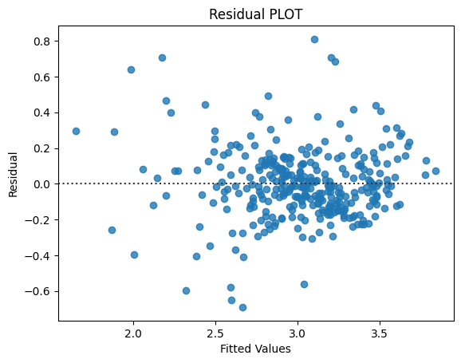

```python
# Predicted values
fitted = model_3.fittedvalues

sns.residplot(x = fitted, y = residuals)
plt.xlabel("Fitted Values")
plt.ylabel("Residual")
plt.title("Residual PLOT")

plt.show()
```

The residuals are randomly and uniformely scattered along the x axis, they do not form any pattern or follow any trend.

### **4. Normality of error terms**

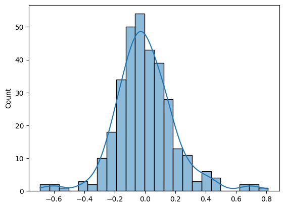

```python
# Plot histogram to see distribution of residuals
sns.histplot(residuals, kde = True)
```

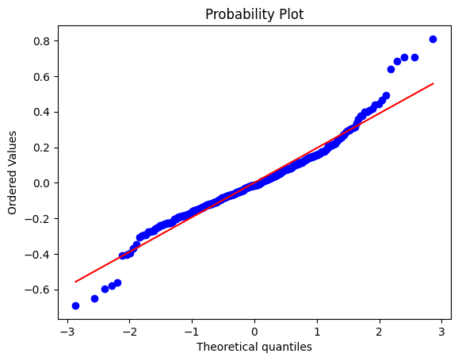

```python
# Q-Q plot to confirm normality
stats.probplot(residuals, dist = "norm", plot = pylab)

plt.show()
```

### Cross Validation

```python
# Fucntion to perform cross validation
def cross_validate_sm_ols(X, y, k = 10):

    "Perform cross validation, takes the values of the dependent variables and the values of the dependent variable"

    kf = KFold(n_splits=k, shuffle=True, random_state=1)
    r2_scores = []
    mape_scores = []

    for train_index, test_index in kf.split(X):
        X_train, X_test = X[train_index], X[test_index]
        y_train, y_test = y[train_index], y[test_index]

        model = sm.OLS(y_train, X_train).fit()
        y_pred = model.predict(X_test)

        r2_scores.append(r2_score(y_test, y_pred))
        mape_scores.append(mean_absolute_percentage_error(y_test, y_pred))

    mean_r2 = np.mean(r2_scores)
    std_r2 = np.std(r2_scores)
    mean_mape = np.mean(mape_scores)
    std_mape = np.std(mape_scores)

    return mean_r2, std_r2, mean_mape, std_mape
```

```python
x_k = x.drop(columns = ['INDUS', 'ZN', 'AGE', 'TAX']) # Discard irrelevant variables
results = []

# Use cross validation function for different values of k
for k in range(2, 16):
    mean_r2, std_r2, mean_mape, std_mape = cross_validate_sm_ols(x_k.values, y.values, k)
    results.append((k, mean_r2, 2 * std_r2, mean_mape, 2 * std_mape))

results_df = pd.DataFrame(results, columns=['k', 'R-squared', ' +/-', 'MAPE', '+/-'])
print(results_df)
```

```
     k  R-squared       +/-      MAPE       +/-
0    2   0.761020  0.001353  0.050294  0.003408
1    3   0.753610  0.053949  0.050856  0.002963
2    4   0.756429  0.057054  0.050685  0.011851
3    5   0.758859  0.055010  0.050164  0.006461
4    6   0.758235  0.065670  0.050351  0.012033
5    7   0.744151  0.170680  0.050682  0.012941
6    8   0.754371  0.091982  0.050322  0.013811
7    9   0.738565  0.175791  0.050489  0.013341
8   10   0.752921  0.179383  0.050380  0.014381
9   11   0.746399  0.163482  0.050318  0.011263
10  12   0.749910  0.175206  0.050410  0.014480
11  13   0.744375  0.174850  0.050201  0.016079
12  14   0.749295  0.184597  0.050273  0.016705
13  15   0.751714  0.194131  0.050286  0.020729
```

Splitting the data a different way does not significantly improve the model's performance, therefore "model_3" performs well.

## Final Model

```python
# The final model would be model_3. Check and display parameters and equation
coef = model_3.params
print(coef)
Equation = "MEDV="
print(Equation, end='\t')
for i in range(len(coef)):
    print('(', coef[i], ') * ', coef.index[i], '+', end = ' ')
```

[output not shown]

- That would be the final regression equation obtained by the model.